# inf_workshop

### Semana 3 - Actividad grupal

**Tema: Estadística Inferencial y Estimación de Parámetros**

### Algunos conceptos que debemos tener en cuenta para esta sección:

- **Población:** es el conjunto de elementos que son objeto de estudio estadístico.
- **Individuo:** cada uno de los elementos de la población.
- El número total de individuos de la población se suele denotar como **N**.
- **Muestra:** es una parte (subconjunto) de la población con la que realmente se realiza el estudio.
- **Tamaño de muestra:** es el número de elementos del que se compone la muestra y se suele denotar como **n**.
- **Estadístico:** cualquier función de la muestra. Por ejemplo, la media o la varianza muestrales son estadísticos.
- **Estimadores:** son estadísticos independientes de los parámetros de la población, y que se utilizan para aproximarlos.

Discutan los siguientes puntos:

#### 1. **Estadística Inferencial:**

- *Definición:* ¿Qué entendemos por Estadística Inferencial? Reflexionemos sobre su propósito y cómo difiere de la estadística descriptiva. Consideremos ejemplos prácticos en los que la inferencia estadística sea relevante.
- *Problemas que Trata:* Identifiquemos los tipos de problemas que aborda la Estadística Inferencial en el análisis de datos, como la estimación de parámetros, la prueba de hipótesis y el análisis de relaciones entre variables.
- *Técnicas Utilizadas:* Examinemos algunas de las técnicas fundamentales que la Estadística Inferencial emplea para realizar inferencias sobre poblaciones a partir de muestras, tales como la estimación puntual, los intervalos de confianza y las pruebas de hipótesis. Discutamos ejemplos concretos de cada técnica.

#### 2. **Estimador:**

- *Definición:* ¿Qué es un estimador y cuál es su función en estadística? ¿Por qué es importante elegir un buen estimador para representar una población?
- *Estimador Puntual:* Detallemos qué significa tener un estimador puntual y discutamos sobre sus características y propiedades, como la consistencia, la insesgadez y la eficiencia.
- *Estimador Por Intervalo:* Expliquemos qué implica tener un estimador por intervalo y cómo se construye un intervalo de confianza. Reflexionemos sobre el significado de los distintos niveles de confianza y su interpretación.

[figure not shown]

#### 3. **Intervalos de Confianza:**

- *Definición:* ¿Qué es un intervalo de confianza? Reflexionemos sobre su interpretación en el contexto de la inferencia estadística. ¿Qué significa que un intervalo tenga un 95% de confianza?
- *Construcción de Intervalos de Confianza:* Analicemos el proceso para construir un intervalo de confianza, considerando la media, la desviación estándar y el tamaño de la muestra. Identifiquemos los factores que influyen en su amplitud y nivel de confianza.
- *Aplicaciones Prácticas:* Discutamos ejemplos prácticos donde se utilizan intervalos de confianza en la toma de decisiones basadas en datos, tales como encuestas de opinión, estudios clínicos o análisis de calidad en procesos industriales.

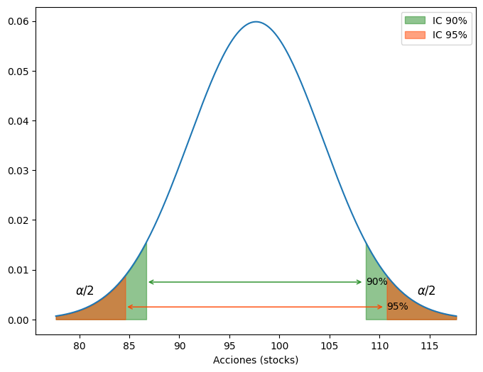

La fórmula general para un intervalo de confianza (IC) se puede expresar como:

$$ \text{IC} = \text{Estimador} \pm \text{Margen de error} $$

Donde:

- **Estimador**: Es el valor puntual calculado a partir de la muestra (por ejemplo, la media muestral $\bar{X}$ o la proporción muestral $\hat{p}$).
- **Margen de error**: Representa la incertidumbre asociada con el estimador y se calcula generalmente como un valor crítico multiplicado por la desviación estándar o el error estándar del estimador.

Este enfoque se aplica a distintos tipos de estimadores (medias, proporciones, diferencias entre medias, etc.) y refleja la variabilidad inherente en las estimaciones basadas en muestras.

4. **Procedimiento para Pruebas de Hipótesis:**
   - *Pasos Básicos:* Esquematicemos el procedimiento para llevar a cabo una prueba de hipótesis. ¿Cómo se plantea y ejecuta una prueba?
   - *Aplicaciones Prácticas:* Discutamos ejemplos prácticos donde se utilizan purebas de hipótesis en la toma de decisiones basadas en datos.
   - *Tipos de Errores:* Analicemos los tipos de errores que pueden ocurrir en una prueba de hipótesis. ¿Cuándo cometemos un error de Tipo I o Tipo II?

Recuerden compartir ejemplos prácticos y experiencias que hayan encontrado en su experiencia profesional relacionados con estos conceptos. ¡La participación activa en esta discusión enriquecerá nuestro entendimiento colectivo!

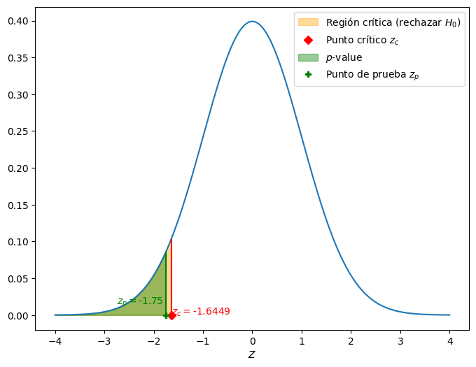

- **Fuentes y recursos:**
  - [Estadística Inferencial: Intervalos de confianza](https://nbviewer.org/github/marsgr6/EN-online/blob/main/statistical_inference.ipynb)
  - [Estadística Inferencial: Pruebas de hipótesis](https://nbviewer.org/github/marsgr6/EN-online/blob/main/statistical_tests.ipynb)

#### De forma autónoma explore los siguientes dos temas:

- **ANOVA:** Una técnica estadística utilizada para comparar las medias de tres o más grupos diferentes para determinar si al menos uno de ellos es significativamente diferente. Para más detalles, puedes revisar el siguiente notebook: [ANOVA](https://nbviewer.org/github/marsgr6/estadistica-ux/blob/main/anova.ipynb)
- **Ajuste de distribuciones (discretas y continuas):** El proceso de identificar la distribución estadística que mejor se ajusta a un conjunto de datos. Puedes revisar ejemplos y pruebas en los siguientes notebooks:
  - [Modelado de distribuciones discretas](https://github.com/marsgr6/r-scripts/blob/master/notebooks/Semana_2_ejemplo_modelado_dist_discretas.ipynb)
  - [Pruebas de ajuste de distribuciones](https://github.com/marsgr6/r-scripts/blob/master/notebooks/Semana_2_test_ia_dist_fitting.ipynb)